# Investigation of the correlation between foot size and mistakes made by students

Pedro Pons

2022-10-27

## Libraries

```r
library(ggplot2)
```

## Data acquiral

The data for this computational document was acquired via the tedious process copying the data from a .pdf document provided in the SMPE repository into a .csv file.

## Data loading

Skipping the header row

```r
data_file = "mistakesByFootSize.csv"
data = read.csv(data_file)
```

## Data visualization

Visualizing basic information about the data

```r
summary(data)
```

```
##     footSize      mistakesMade
##  Min.   :17.50   Min.   : 0.000
##  1st Qu.:20.50   1st Qu.: 4.000
##  Median :23.50   Median : 8.500
##  Mean   :23.26   Mean   : 9.118
##  3rd Qu.:26.50   3rd Qu.:14.000
##  Max.   :29.00   Max.   :20.000
```

Note that the mean foot size in this study is below both the foot size averages for both American women (24.5cm) and men (27.3), which indicates it was done on underage students.

### Plotting

Since we are dealing with only two variables, we can visually inspect whether there is a correlation between them with a scatter plot

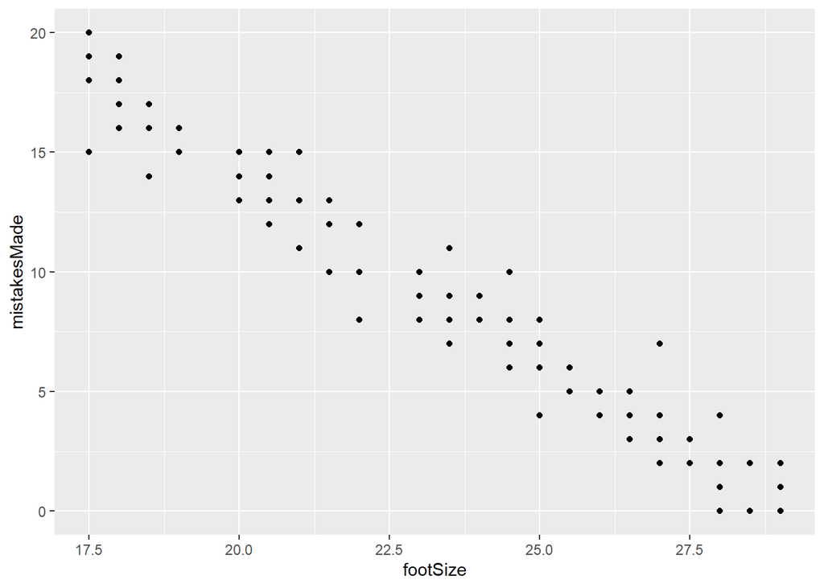

```r
# plot(data) - avoids using GGPLOT
ggplot(data, aes(x=footSize, y=mistakesMade)) + geom_point()
```

From this visualization, we’d gather there is a clear negative correlation between those variables; the larger the foot, the fewer mistakes made. This can be confirmed programmatically:

```r
cor(x = data["footSize"], y = data["mistakesMade"])
```

```
##          mistakesMade
## footSize   -0.9697978
```

Can any conclusions be drawn from this? No, correlation does not mean causation. For instance, we are not controlling for other relevant variables such as age, which are correlated with foot size and level of education of the students.

The other problem here is the incredibly small sample, which by itself could be enough to remove any credibility from this toy study.